# Project №4

# 1 Brief exploratory data analysis

A brief exploratory analysis of the data was carried out in order to identify some missing values in our data, find errors in values.

```
##   futime fustat     age resid.ds rx ecog.ps
## 1     59      1 72.3315        2  1       1
## 2    115      1 74.4932        2  1       1
## 3    156      1 66.4658        2  1       2
## 4    421      0 53.3644        2  2       1
## 5    431      1 50.3397        2  1       1
## 6    448      0 56.4301        1  1       2
```

We visualized possible outliers in a futime variable. As you can see on the graph there are no strong outliers.

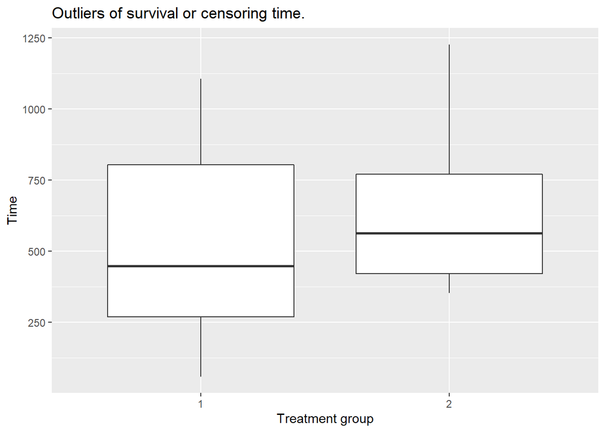

It may also be helpful to estimate the minimum and maximum age of the patients so that there are no inadequate values.

So age of the oldest patient 74.5041 and the youungest patient is 38.8932 years old. Age within normal limits.

There are 26 observations in our dataframe and 26 of them are full (without NA).

In addition, we expect that the average time for censored and uncensored cases should differ. We visualize it

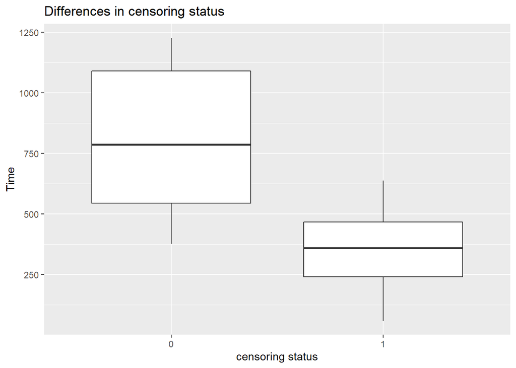

As we can see mean time differs depending on censoring status.

# 2 Kaplan-Meier curves

We built a survival curve based on the whole model

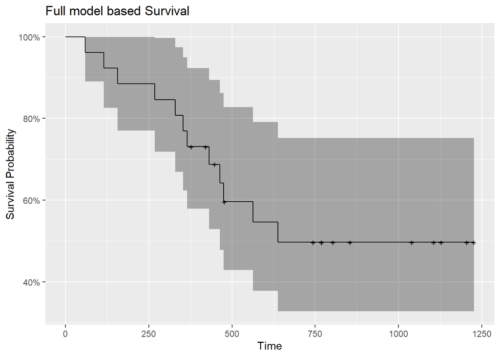

After that, we analyzed how the individual factors dividing patients into groups affect their survival.

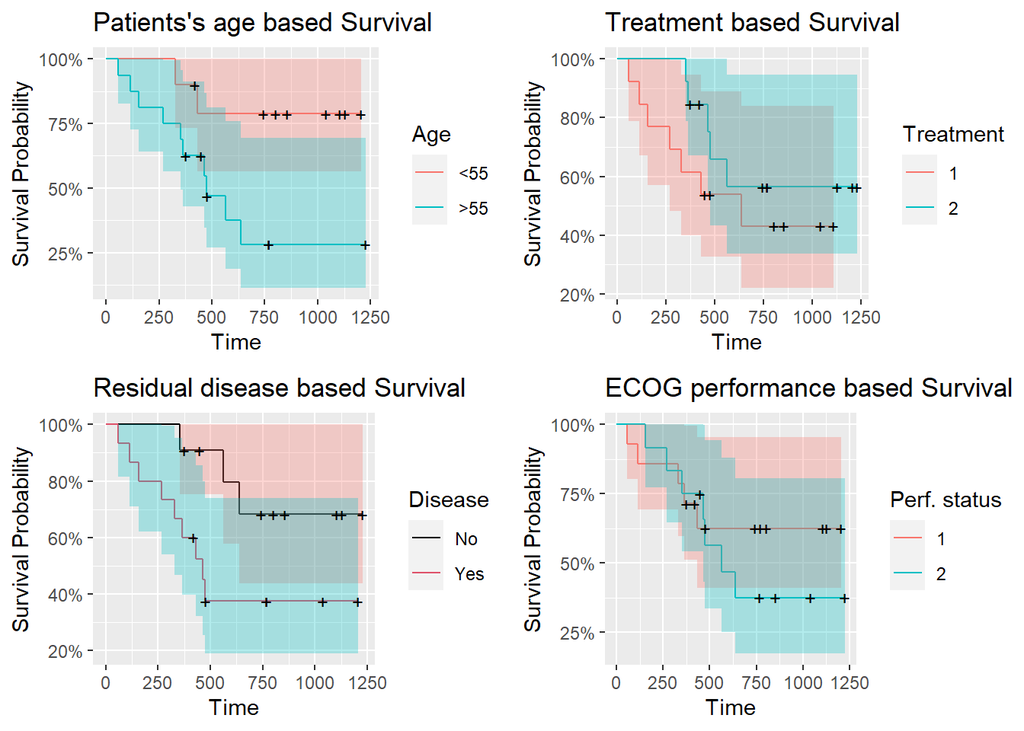

We can see that the groups differ in terms of survival among themselves, but so far we cannot conclude the significance of these differences

# 3 Log-rank tests

We ran log rank tests to assess the significance of the differences in our groups

```
##
##  Asymptotic Two-Sample Logrank Test
##
## data:  Surv(futime, fustat) by as.factor(rx) (1, 2)
## Z = -1.0296, p-value = 0.3032
## alternative hypothesis: true theta is not equal to 1
```

```
##
##  Asymptotic Two-Sample Logrank Test
##
## data:  Surv(futime, fustat) by as.factor(resid.ds) (1, 2)
## Z = 1.9234, p-value = 0.05444
## alternative hypothesis: true theta is not equal to 1
```

```
##
##  Asymptotic Two-Sample Logrank Test
##
## data:  Surv(futime, fustat) by as.factor(AG) (<55, >55)
## Z = 2.1721, p-value = 0.02985
## alternative hypothesis: true theta is not equal to 1
```

```
##
##  Asymptotic Two-Sample Logrank Test
##
## data:  Surv(futime, fustat) by as.factor(ecog.ps) (1, 2)
## Z = 0.69106, p-value = 0.4895
## alternative hypothesis: true theta is not equal to 1
```

As we can see, there are significant differences only in the age group (more or less than 55)

# 4 Analysis of factors influencing the risk (Cox model)

We built Cox model to assess the factors influencing the risk

```
## Call:
## coxph(formula = Surv(futime, fustat) ~ rx + AG + resid.ds + ecog.ps,
##     data = old_p)
##
##   n= 26, number of events= 12
##
##             coef exp(coef) se(coef)      z Pr(>|z|)
## rx       -1.2731    0.2800   0.6419 -1.983   0.0473 *
## AG>55     1.7432    5.7157   0.8175  2.132   0.0330 *
## resid.ds  1.3330    3.7926   0.7328  1.819   0.0689 .
## ecog.ps   0.2093    1.2329   0.6309  0.332   0.7400
## ---
## Signif. codes:  0 '***' 0.001 '**' 0.01 '*' 0.05 '.' 0.1 ' ' 1
##
##          exp(coef) exp(-coef) lower .95 upper .95
## rx           0.280     3.5717   0.07957    0.9851
## AG>55        5.716     0.1750   1.15132   28.3749
## resid.ds     3.793     0.2637   0.90200   15.9465
## ecog.ps      1.233     0.8111   0.35804    4.2452
##
## Concordance= 0.771  (se = 0.066 )
## Likelihood ratio test= 11.79  on 4 df,   p=0.02
## Wald test            = 9.06  on 4 df,   p=0.06
## Score (logrank) test = 10.83  on 4 df,   p=0.03
```

As we can see treatment group and age factors are significant.

Nevertheless, it is necessary to check how these factors relate to each other and to the remaining variables.

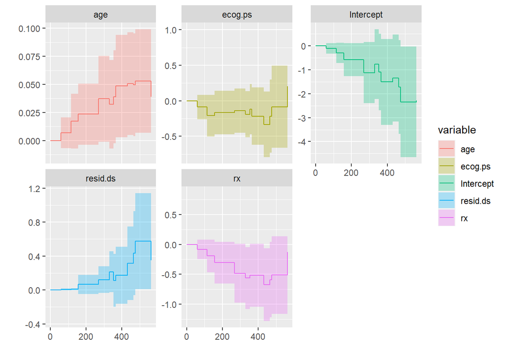

According to the graph, we can assume that age is associated with the appearance of residual diseases (which is quite logical from a biological point of view). However, age and treatment factors are not related. accordingly they pose a risk (for patients divided into two groups >55 and <55 years old)

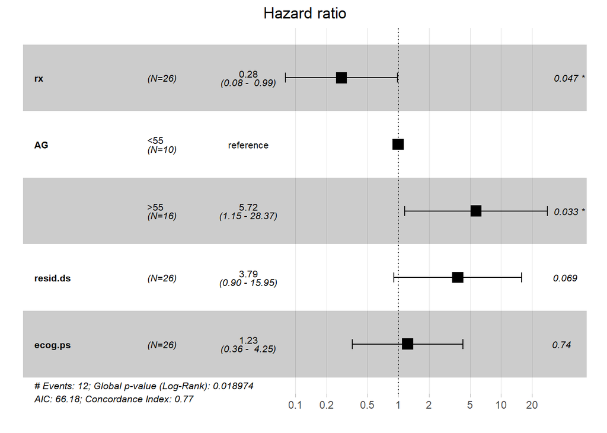

However, it is important to note that if all patients are not divided into two groups by age, then the only significant factor will remain the age itself. The Cox model will be the following

```
## Call:
## coxph(formula = Surv(futime, fustat) ~ rx + age + resid.ds +
##     ecog.ps, data = old_p)
##
##              coef exp(coef) se(coef)      z       p
## rx       -0.91450   0.40072  0.65332 -1.400 0.16158
## age       0.12481   1.13294  0.04689  2.662 0.00777
## resid.ds  0.82619   2.28459  0.78961  1.046 0.29541
## ecog.ps   0.33621   1.39964  0.64392  0.522 0.60158
##
## Likelihood ratio test=17.04  on 4 df, p=0.001896
## n= 26, number of events= 12
```